# Ford GoBike System Data Exploration

## by Martin Tschendel

## Investigation Overview

I investigate a data set what includes information about individual rides made in a bike-sharing system covering the greater San Francisco Bay area. Source of data: https://www.fordgobike.com/system-data

## Dataset Overview

There are nearly 1.9 Mio.individual ride entries in this dataset and they have 10 features. We can find variables with quantitative nature like the duration of each ride (duration_sec) and categorical variables like type of users (user_type).

### Main Questions

- When are most trips taken in terms of time of day, day of the week, or month of the year?
- How long does the average trip take?
- Does the above depend on if a user is a subscriber or customer?
- Where are the stations located and how how many bikes are rented there per year?

## Univariate Exploration

**Number of Rides Across Different Hours of the Day**  
At first we will start to look at the distribution of rides across different times intervalls: time of day, day of the week and month of the year. Here we want to find answers to the question: When are most trips taken in terms of time of day, day of the week, or month of the year?

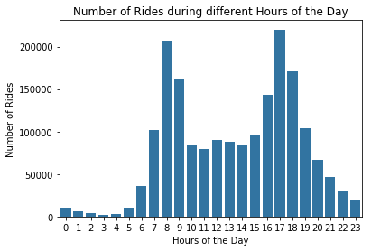

```python
#plot the number of rides per hour of the day
base_color = sb.color_palette()[0]
sb.countplot(data = df_18, x = 'hour', color = base_color);
plt.xlabel("Hours of the Day")
plt.ylabel("Number of Rides")
plt.title("Number of Rides during different Hours of the Day");
```

## Observations and next steps

We can see that most of the rides happen in the morning and evening times during the peak hours. Next, we examine distribution of rides across different days of the week.

**Number of Rides Across Different Days of the Week**

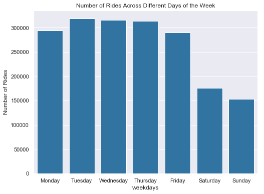

```python
#plot the number of rides in different weekdays
order = ['Monday', 'Tuesday', 'Wednesday', 'Thursday', 'Friday', 'Saturday', 'Sunday']
base_color = sb.color_palette()[0]
sb.set(rc={'figure.figsize':(8,6)})
sb.countplot(data = df_18, x = 'weekday', color = base_color, order = order);
plt.xlabel("weekdays")
plt.ylabel("Number of Rides")
plt.title("Number of Rides Across Different Days of the Week");
```

## Observations and next steps

We can see that most of the rides happen during the working days. Fewer rides happen during the weekends. Next, we examine distribution of rides across different months of the year.

**Number of Rides across Different Months of the Year**

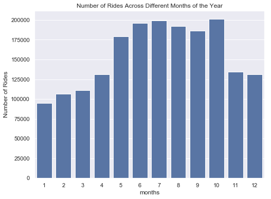

```python
#plot the number of rides in different months
base_color = sb.color_palette()[0]
sb.countplot(data = df_18, x = 'month', color = base_color);
plt.xlabel("months")
plt.ylabel("Number of Rides")
plt.title("Number of Rides Across Different Months of the Year");
```

## Observations and next steps

We can see that most of the rides happen during the summer and autumn. Fewer rides happen during the winter months. Different to the winter months, October has normally warm temperatures and few rainy days in the Bay Area. Next, we only examine number of rides across hours during working days or weekends.

**Number of Rides Across Hours During Working Days or Weekends**

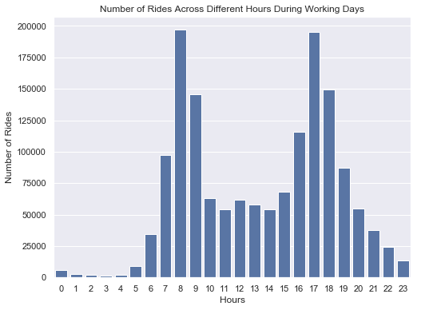

```python
#plot the number of rides during different hours in working days
base_color = sb.color_palette()[0]
sb.countplot(data = df_18_1, x = 'hour', color = base_color);
plt.xlabel("Hours")
plt.ylabel("Number of Rides")
plt.title("Number of Rides Across Different Hours During Working Days");
```

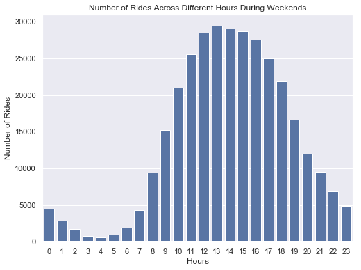

```python
#plot the number of rides during different hours in the weekend
base_color = sb.color_palette()[0]
sb.countplot(data = df_18_2, x = 'hour', color = base_color);
plt.xlabel("Hours")
plt.ylabel("Number of Rides")
plt.title("Number of Rides Across Different Hours During Weekends");
```

## Observations

There is a clear difference in the distribution of rides across hours between working days and weekends. During working days, most of the bikes are rented during morning and evening peak hours, whereas the most bike rentals during the weekend happen in the noon and afternoon time. If we compare the count of the rentals, we can see that the maximum of the rentals during specific hours is higher during the working days, for example, nearly 200,000 rides happen at 8am or 5pm respectively. In contrast to that, 1pm, what is the average hour with the maximum bike rentals during the weekends, only has a bit less than 30,000 counts.  
From the data visualization, we realize that more the rides are happening during working days than during weekends. In addition, the rental peaks happen during the morning and evening hours in the working days and during the noon and afternoon times in the weekends. Summer and autumn months are have more rentals than winter months.

## Bivariate Exploration

Here we want to find answers to the following questions:

- How long does the average trip take?
- Does the above depend on if a user is a subscriber or customer?

At first we are interested in the trip time between males/females, between different days in a week and between different unser types.

**Trip time of males and females**

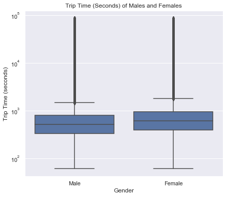

```python
#plot trip time of males and females
f, ax = plt.subplots(figsize=(7, 6))
ax.set_yscale("log")
sb.boxplot(data = df_18_3, x = 'member_gender', y = 'duration_sec', color = base_color);
plt.xlabel("Gender")
plt.ylabel("Trip Time (seconds)")
plt.title("Trip Time (Seconds) of Males and Females");
```

## Observations and next steps

We can see that the median as weel as the values for the first quartile (Q1) and the third quartile (Q3) with regard to the duration of rides conducted by females are higher than by males. Now we want to see duration of rides across different days.

**Trip time across different days of the week**

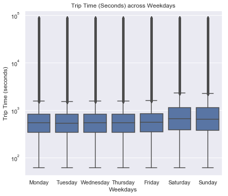

```python
#put weekdays in right order and use log scale
f, ax = plt.subplots(figsize=(7, 6))
ax.set_yscale("log")
order = ['Monday', 'Tuesday', 'Wednesday', 'Thursday', 'Friday', 'Saturday', 'Sunday']
sb.boxplot(data = df_18, x = 'weekday', y = 'duration_sec', color = base_color, order = order);
plt.xlabel("Weekdays")
plt.ylabel("Trip Time (seconds)")
plt.title("Trip Time (Seconds) across Weekdays");
```

## Observations and next steps

We can see that the median as well as the values for Q1 and Q3 with regard to the duration of rides during the weekend are higher than during weekdays. Now we want to see duration of rides across different user types.

**Duration of rides between different user types**

- "Subscriber" = Member
- "Customer" = Casual

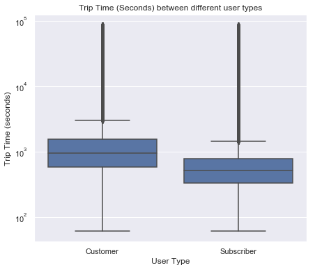

```python
#plot trip time between different user types with a log scale
f, ax = plt.subplots(figsize=(7, 6))
ax.set_yscale("log")
sb.boxplot(data = df_18, x = 'user_type', y = 'duration_sec', color = base_color);
plt.xlabel("User Type")
plt.ylabel("Trip Time (seconds)")
plt.title("Trip Time (Seconds) between different user types");
```

## Observations and next steps

We can see that the median as well as the values for Q1 and Q3 with regard to the duration of rides of customers are higher than of subscribers. Now we want to see the distribution of customer's and subscriber's rides across different days.

**Distribution of customer's and subscriber's rides across different days.**

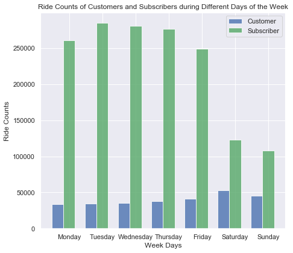

```python
#data to plot
order = ['Monday', 'Tuesday', 'Wednesday', 'Thursday', 'Friday', 'Saturday', 'Sunday']
df_users_1
n_groups = 7

#create plot
fig, ax = plt.subplots(figsize=(7, 6))
index = np.arange(n_groups)
bar_width = 0.35
opacity = 0.8

rects1 = plt.bar(index, df_users_1.loc[order].Customer, bar_width,
                alpha=opacity,
                color='b',
                label='Customer')

rects2 = plt.bar(index + bar_width, df_users_1.loc[order].Subscriber, bar_width,
                alpha=opacity,
                color='g',
                label='Subscriber')

plt.xlabel('Week Days')
plt.ylabel('Ride Counts')
plt.title('Ride Counts of Customers and Subscribers during Different Days of the Week')
plt.xticks(index + bar_width, ('Monday', 'Tuesday', 'Wednesday', 'Thursday', 'Friday', 'Saturday', 'Sunday'))
plt.legend()

plt.tight_layout()
plt.show()
```

### Observations

In this part of the observation, we have been was mainly interested in different trip times between males and females as well as between user groups (customers and subscribers). From the plots above, we can realize that the median of trip duration for females is higher than for males and that the median of trip duration for customers is higher than for subscribers. We can also see that the median of trip duration during the weekend is higher than during working days.

We can observe one interesting relationship between ride counts of different user groups during different days of the week. The ride counts of subscribers are higher during the working days and less during the weekend. In contrast to that, the ride counts of customers are less during working days and higher during the weekend. It could be that most of the subscribers are using the bike in order to commute from their home to the office, but they might use it less frequently for leisure purpose.

## Multivariate Exploration

Here we want to find answers to the following questions:

- Where are the stations located and how many bikes are rented there per year?

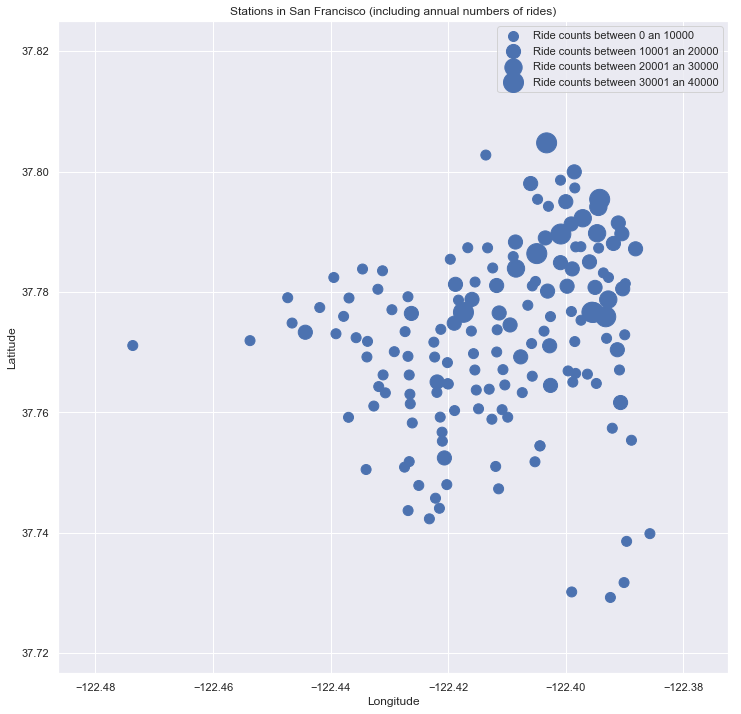

```python
#show spatial distribution of stations in San Francisco (including annual numbers of rides)
import matplotlib.patches as mpatches

plt.figure(figsize=(12, 12))
plt.scatter(data = station_SF, x = 'start_station_longitude', y = 'start_station_latitude', s = 'count_cat');


# dummy series for adding legend
sizes = [100, 200, 300, 400]
base_color = sb.color_palette()[0]
legend_obj = []
for s in sizes:
    legend_obj.append(plt.scatter([], [], s = s, color = base_color))
L = plt.legend(legend_obj, sizes);
L.get_texts()[0].set_text('Ride counts between 0 an 10000')
L.get_texts()[1].set_text('Ride counts between 10001 an 20000')
L.get_texts()[2].set_text('Ride counts between 20001 an 30000')
L.get_texts()[3].set_text('Ride counts between 30001 an 40000')

plt.xlabel("Longitude")
plt.ylabel("Latitude")
plt.title("Stations in San Francisco (including annual numbers of rides)");
```

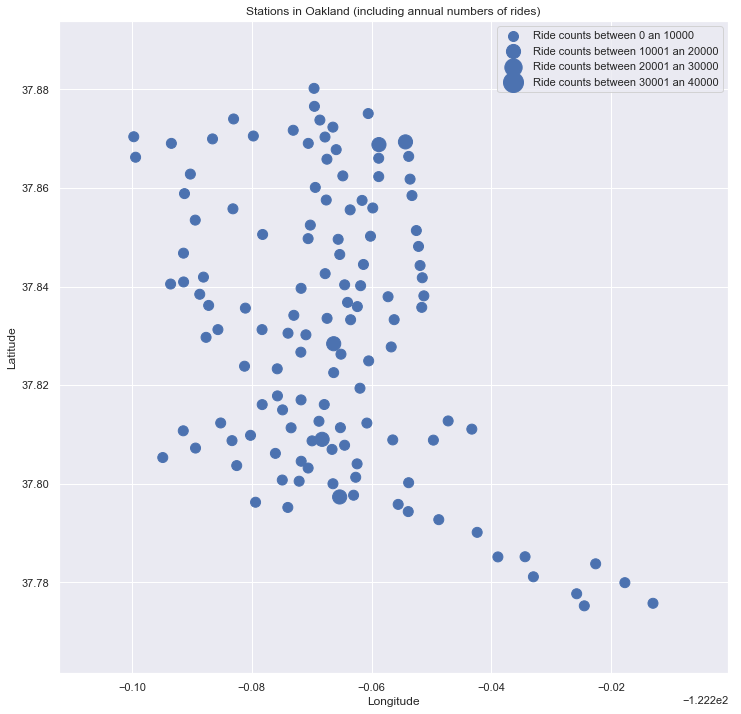

```python
#show spatial distribution of stations in Oakland (including annual numbers of rides)
import matplotlib.patches as mpatches

plt.figure(figsize=(12, 12))
plt.scatter(data = station_OA, x = 'start_station_longitude', y = 'start_station_latitude', s = 'count_cat');

# dummy series for adding legend
sizes = [100, 200, 300, 400]
base_color = sb.color_palette()[0]
legend_obj = []
for s in sizes:
    legend_obj.append(plt.scatter([], [], s = s, color = base_color))
L = plt.legend(legend_obj, sizes);
L.get_texts()[0].set_text('Ride counts between 0 an 10000')
L.get_texts()[1].set_text('Ride counts between 10001 an 20000')
L.get_texts()[2].set_text('Ride counts between 20001 an 30000')
L.get_texts()[3].set_text('Ride counts between 30001 an 40000')

plt.xlabel("Longitude")
plt.ylabel("Latitude")
plt.title("Stations in Oakland (including annual numbers of rides)");
```

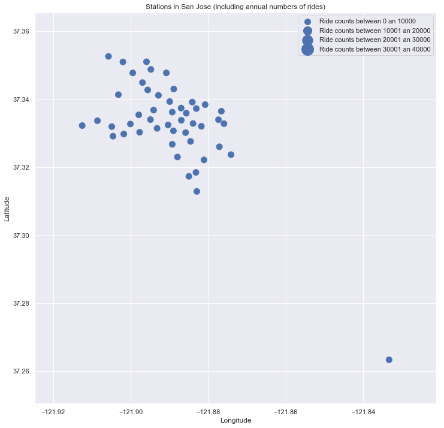

```python
#show spatial distribution of stations in San Jose (including annual numbers of rides)
import matplotlib.patches as mpatches

plt.figure(figsize=(12, 12))
plt.scatter(data = station_SJ, x = 'start_station_longitude', y = 'start_station_latitude', s = 'count_cat');

# dummy series for adding legend
sizes = [100, 200, 300, 400]
base_color = sb.color_palette()[0]
legend_obj = []
for s in sizes:
    legend_obj.append(plt.scatter([], [], s = s, color = base_color))
L = plt.legend(legend_obj, sizes);
L.get_texts()[0].set_text('Ride counts between 0 an 10000')
L.get_texts()[1].set_text('Ride counts between 10001 an 20000')
L.get_texts()[2].set_text('Ride counts between 20001 an 30000')
L.get_texts()[3].set_text('Ride counts between 30001 an 40000')

plt.xlabel("Longitude")
plt.ylabel("Latitude")
plt.title("Stations in San Jose (including annual numbers of rides)");
```

### Observations

In this part I observed that the dataset actually consists of three different cities in the San Francisco Bay Area. I also found out that the stations in San Francisco have the highest number of ride counts (they mainly concentrate in the Financial District), followed by the cities of Oakland and San Jose.